# Reproducible Research: Peer Assessment 1

C.C.

### Loading and preprocessing the data

```r
library(kernlab)
library(ggplot2)

if(!file.exists("activity.csv")) {
        unzip("RepData_PeerAssessment1-master/activity.zip")}

activity<-read.csv("D:/R-programming/RepData_PeerAssessment1-master/activity.csv", header = TRUE, sep = ",", )
activity$date <- as.Date(activity$date, "%Y-%m-%d")
activity_no.na <- activity[complete.cases(activity),]
```

## What is mean total number of steps taken per day?

#### Calculate the total number of steps taken per day

```r
daily.total.steps <- tapply(activity$steps, activity$date, sum, na.rm = TRUE)
```

#### Make a histogram of the total number of steps taken each day

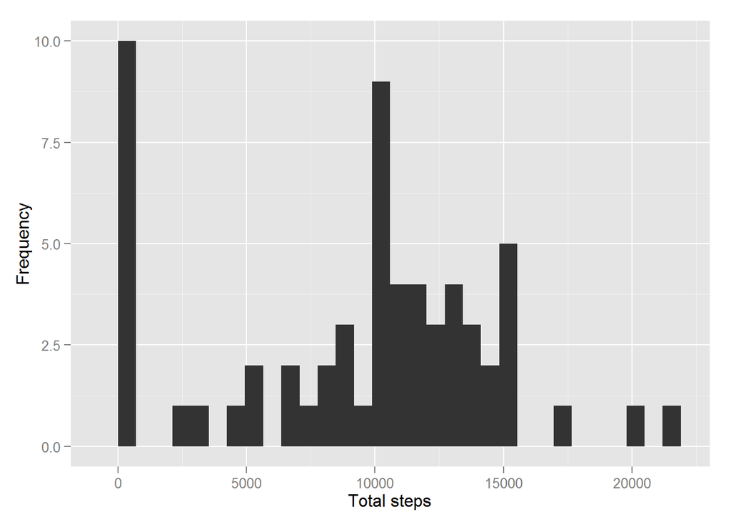

```r
qplot(daily.total.steps, xlab = "Total steps", ylab = "Frequency")
```

#### Calculate and report the mean and median of the total number of steps taken per day

```r
mean <- mean(daily.total.steps)
mean
```

```
## [1] 9354.23
```

```r
median <- median(daily.total.steps)
median
```

```
## [1] 10395
```

## What is the average daily activity pattern?

#### Make a time series plot of the 5-minute interval and the average number of steps

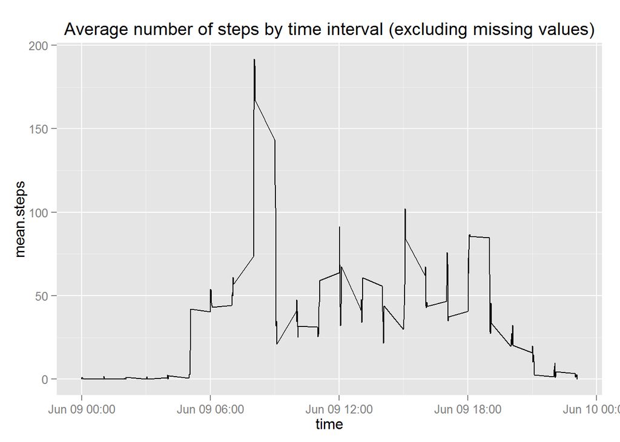

```r
time <- formatC(activity$interval/100, 1, format= "f")
activity$date.time <- as.POSIXct(paste(activity$date, time), format = "%Y-%m-%d %H.%M", tz = "GMT")
activity$time <- format(activity$date.time, format = "%H:%M:%S")
activity$time <- as.POSIXct(activity$time, format = "%H:%M:%S")
mean.steps <- tapply(activity$steps, activity$time, mean, na.rm = TRUE)
daily.pattern <- data.frame(time = as.POSIXct(names(mean.steps)), mean.steps = mean.steps)

ggplot(daily.pattern , aes(time, mean.steps)) + geom_line() + labs(title = expression("Average number of steps by time interval (excluding missing values)"))+ scale_x_datetime(minor_breaks = waiver())
```

#### Which 5-minute interval, on average across all the days in the dataset, contains the maximum number of steps?

```r
most <- which.max(daily.pattern$mean.steps)
format(daily.pattern[most, "time"], format = "%H:%M")
```

```
## [1] "08:03"
```

## Imputing missing values

#### Calculate and report the total number of missing values in the dataset

```r
total_na <- sum(is.na(activity$steps))
total_na
```

```
## [1] 2304
```

```r
percent_na <- paste(round(sum(is.na(activity$steps))/nrow(activity),2)*100,"%")
percent_na
```

```
## [1] "13 %"
```

```r
new_activity<-activity

for (i in 1:length(new_activity$steps)) {
        if (is.na(new_activity[i, 1])) {steps_average <- subset(daily.pattern, daily.pattern$mean.steps == as.numeric(activity[i, 3]))$steps}


}
count_na <- sum(is.na(new_activity$steps))
```

```r
head(new_activity)
```

```
##   steps       date interval           date.time                time
## 1    NA 2012-10-01        0 2012-10-01 00:00:00 2015-06-09 00:00:00
## 2    NA 2012-10-01        5 2012-10-01 00:00:00 2015-06-09 00:00:00
## 3    NA 2012-10-01       10 2012-10-01 00:01:00 2015-06-09 00:01:00
## 4    NA 2012-10-01       15 2012-10-01 00:01:00 2015-06-09 00:01:00
## 5    NA 2012-10-01       20 2012-10-01 00:02:00 2015-06-09 00:02:00
## 6    NA 2012-10-01       25 2012-10-01 00:02:00 2015-06-09 00:02:00
```

[figure not shown]

```r
ggplot(new_activity, aes(date, steps)) + geom_histogram(breaks = c(0,2500, 5000, 7500, 10000, 12500, 15000, 17500, 20000,22500, 25000), stat="identity") + labs(y = expression("Number of steps per day")) + labs(x = expression("days")) + labs(title = expression("Total Number of steps per day (after filling in missing values)"))
```

```r
mean2<-round(mean(daily.pattern$mean.steps),4)
median2<-round(median(daily.pattern$mean.steps),4)
delta_mean<-(mean-mean2)/mean
paste(round(100*delta_mean, 4), "%")
```

```
## [1] "99.5963 %"
```

```r
delta_median<-(median-median2)/median
paste(round(100*delta_median, 4), "%")
```

```
## [1] "99.6699 %"
```

## Are there differences in activity patterns between weekdays and weekends?

#### Create a new factor variable in the dataset with two levels – “weekday” and “weekend” indicating whether a given date is a weekday or weekend day.

```r
weekend_log <- grepl("^[Ss]", weekdays(as.Date(new_activity$date)))

for (i in (1:nrow(new_activity))) {
        if (weekend_log[i] == TRUE) {
                new_activity$day_of_week[i] <- "weekend"
        } else {
                new_activity$day_of_week[i] <- "weekday"
        }
}

summary <- aggregate(new_activity$steps, list(interval = new_activity$interval, day = new_activity$day), mean)
names(summary) <- c("interval", "day", "steps")
```

#### Make a panel plot containing a time series plot of the 5-minute interval (x-axis) and the average number of steps taken, averaged across all weekday days or weekend days (y-axis).

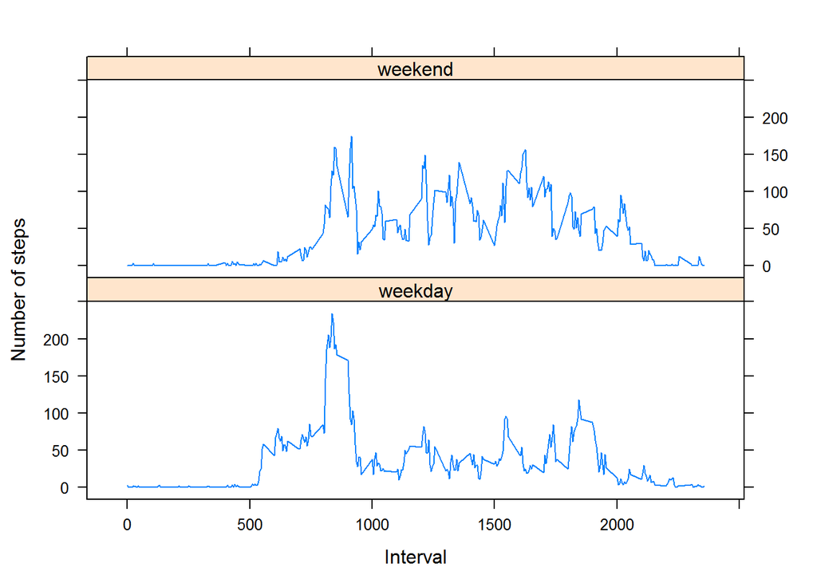

```r
new_activity_no.na <- new_activity[complete.cases(new_activity),]
summary <- aggregate(new_activity_no.na$steps,
                     list(interval = new_activity_no.na$interval, day = new_activity_no.na$day_of_week),
                     mean)
names(summary) <- c("interval", "day", "steps")

library("lattice")

xyplot(summary$steps ~ summary$interval | summary$day,
       layout = c(1, 2), type = "l",
       xlab = "Interval", ylab = "Number of steps")
```